# NF-kB sites

Панюшев Николай

29 марта 2017 г

## Цель и задачи этого маленького проектика

Я решил подобрать праймеры для контроля чипсековской библиотеки для секвенирования, чтобы контролировать обогащение. Если эксперимент прошел успешно, то в IP сигнал должен быть гораздо сильнее, чем в IP c неспецифическими IgG.

Chip-seq мы будем проводить на H1299, а на них экспериментов не делалось, к сожалению.

Поэтому я решил взять клеточные линии: A549, SGBS, IMR90, HeLa, HUVEC, MCF7 и отобрать из них самые мощные пики. Итак, посмотрим, что из этого вышло.

## Импорт данных

Сделаем функцию, которая будет нам данные считывать и сразу фильтровать

Добавить сюда штуку, которая будет levels от хромосом переименовывать и в правильном порядке расставлять

```r
read.narrowpeak <- function(filename, filtering=TRUE){
  raw_peaks <-  read.table(filename, header = F, sep = "\t")
  names(raw_peaks) <- c("Chromosome", "Start", "Stop", "Peak_name",
                        "display_int", "dot",
                        "fold_change", "p-value", "q-value",
                        "summit_position_from_start")

  if (filtering == TRUE){
    #Выбросим неинформативные колонки
    raw_peaks$dot = raw_peaks$display_int <- NULL
    #удаляем хромосомы, которые странно называются
    raw_peaks <- raw_peaks[grep(pattern = "chr\\w\\d?", raw_peaks$Chromosome), ]
    #Митохондриалку тоже выбросим, там не должно быть ТФ
    raw_peaks <- raw_peaks[!raw_peaks$Chromosome == "chrM",]
    #Переставим имена хромосом в нормальном порядке
    raw_peaks$Chromosome <- factor(raw_peaks$Chromosome,
                                   levels =c("chr1","chr2","chr3","chr4","chr5",
                                    "chr6","chr7","chr8","chr9","chr10",
                                    "chr11", "chr12", "chr13", "chr14", "chr15",
                                    "chr16", "chr17", "chr18", "chr19", "chr20",
                                    "chr21", "chr22", "chrX", "chrY"))
    droplevels(raw_peaks)
    raw_peaks <- as.data.table(raw_peaks)
    }
  return(raw_peaks)
}
```

Теперь считаем файлы с пиками с помощью этой чудодейственной функции

```r
A549_peaks <- read.narrowpeak("MACS2_p65_peaks/A549_TNF_vs_bg_peaks.narrowPeak")
HeLa_peaks <- read.narrowpeak("MACS2_p65_peaks/HELA_TNFvsDMSO_peaks.narrowPeak")
HUVEC_peaks <- read.narrowpeak("MACS2_p65_peaks/HUVEC_TNFvsASIS_peaks.narrowPeak")
IMR90_peaks <- read.narrowpeak("MACS2_p65_peaks/IMR90_TNFvsASIS_peaks.narrowPeak")
MCF7_peaks <- read.narrowpeak("MACS2_p65_peaks/MCF7_TNFvsVeh_peaks.narrowPeak")
SGBS_peaks <- read.narrowpeak("MACS2_p65_peaks/SGBS_TNFvsVeh_peaks.narrowPeak")
```

Итак, количество пиков по линиям

- A549 - 17451
- HeLa - 150 - очень мало!
- HUVEC - 16464
- IMR90 - 28931
- MCF7 - 328 - очень мало!
- SGBS - 62570

Скорее всего, либо ошибка при пик-коллинге, или не прошла активация TNF. На вопрос, где ошибка, нам помогут ответить модельки, которые нам выдавал MACS2.

Картинка показывает насколько пики на + и - цепи смещены относительно друг друга. Если все сработало верно, то должно быть хорошее бимодальное распределение. Величина сдвига должна быть близка к размеру нуклеосомы.

Клеточная линия

Величина сдвига

Распределение ридов

A549

261 п.н.

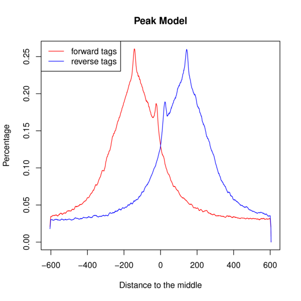

HUVEC

115 п.н.

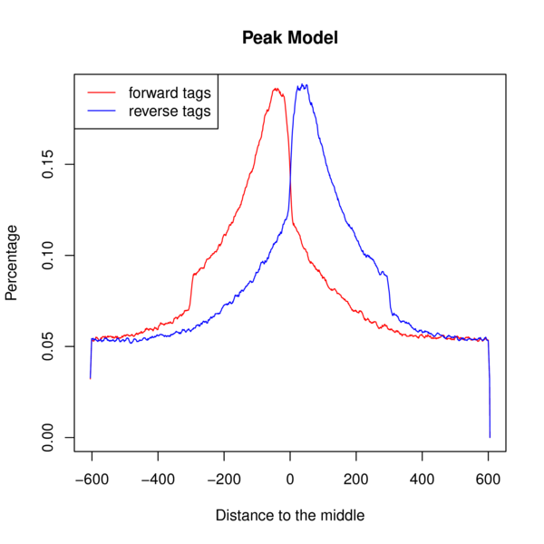

IMR90

141 п.н.

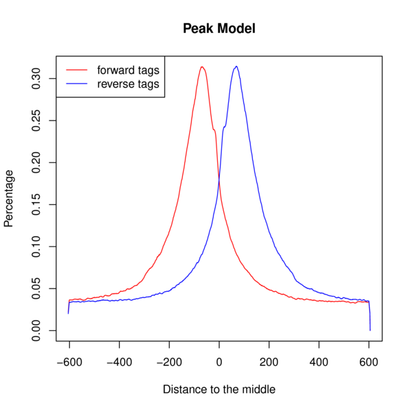

SGBS

161 п.н.

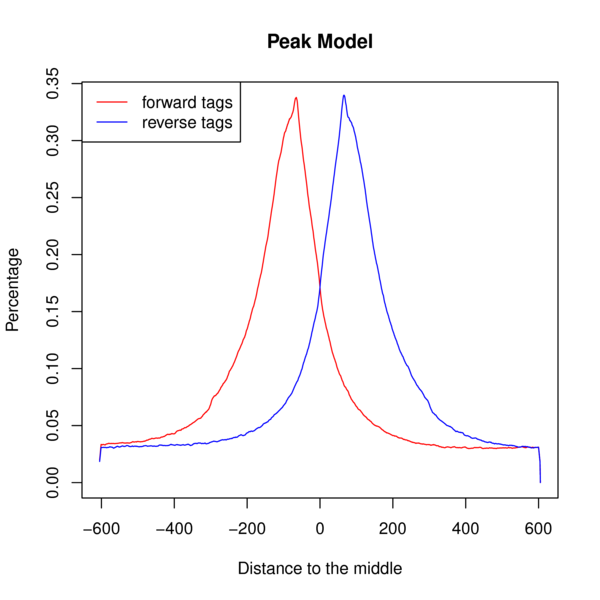

HeLa

34, 96, 500 п.н.

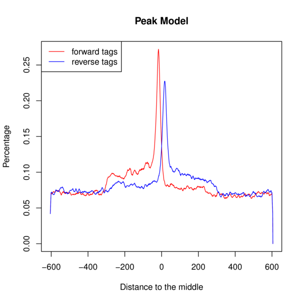

MCF7

148 п.н.

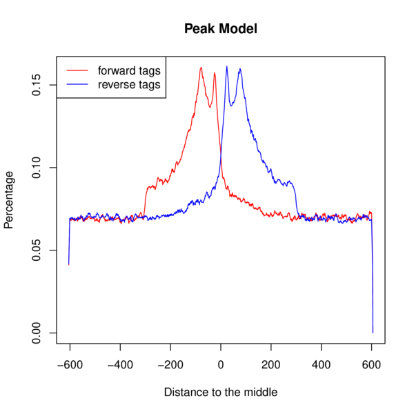

Итак, видим, что в HeLa какие-то проблемы с секвенированием произошли, и/или с экспериментом, поэтому от их использования придется отказаться.  
MCF7 - выглядит лучше, чем HeLa, но с ними тоже не все хорошо, откажемся от них  
A549 - Вызывает опасения, не очень красивое распределение и великоват сдвиг, но мы все равно попробуем с ними поработать.

Cложим все пики вместе, чтобы не возиться с 4мя датасетами, а сразу их объединить.

```r
A549_peaks$Cell_line <- "A549"
HUVEC_peaks$Cell_line <- "HUVEC"
IMR90_peaks$Cell_line <- "IMR90"
SGBS_peaks$Cell_line <- "SGBS"
all_peaks <- rbindlist(list(A549_peaks, HUVEC_peaks, IMR90_peaks, SGBS_peaks))
```

Теперь проанализируем fold_change, он должен давать нормальное распределение, что было бы вполне логично, и оно должно быть примерно одинаковым в разных линиях

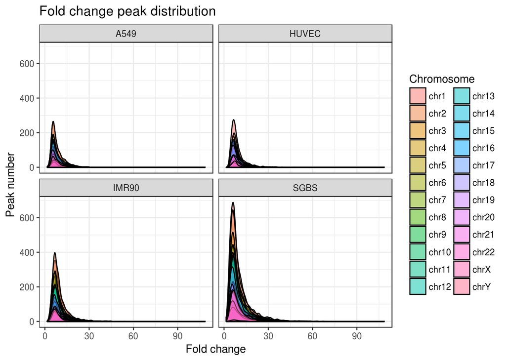

Прикольно, что у SGBS пиков аж в 3 раза больше, надо это взять на заметку! Интересно, почему? Видимо, дело либо в клетках, либо сделано слишком много ридов  
Посмотрим на цифры:

```
##    Chromosome A549 HUVEC IMR90 SGBS
## 1        chr1 1522  1718  2561 5856
## 2        chr2 1515  1250  2796 5326
## 3        chr3 1038  1067  1994 4274
## 4        chr4  650   526  1529 3021
## 5        chr5  999   882  1829 3684
## 6        chr6 1028   990  1965 3822
## 7        chr7  961   722  1536 3280
## 8        chr8  880   679  1514 2959
## 9        chr9  817   688  1442 2791
## 10      chr10  927   794  1452 3143
## 11      chr11  833   911  1434 3099
## 12      chr12  976   817  1416 3145
## 13      chr13  279   318   787 1539
## 14      chr14  594   556   833 1942
## 15      chr15  665   676  1014 1998
## 16      chr16  521   658   794 1940
## 17      chr17  898   913  1027 2659
## 18      chr18  323   294   683 1361
## 19      chr19  535   723   386 1775
## 20      chr20  606   508   608 1624
## 21      chr21  188   204   408  749
## 22      chr22  319   391   443 1042
## 23       chrX  377   179   477 1465
## 24       chrY   NA    NA     3   76
```

Видно, что A549 и HUVEC очень похожи по количеству пиков.

Построим для всех этих пиков гистограммку распределения пиков по хромосомам

И еще заменим подписи снизу гистограммы на номер хромосомы сверху, и уберем расцветку

И добавим туда линию, которая нам покажет, как уменьшаются хромосомы по мере возрастания их номера. !!!(Не сделано пока что)!!!

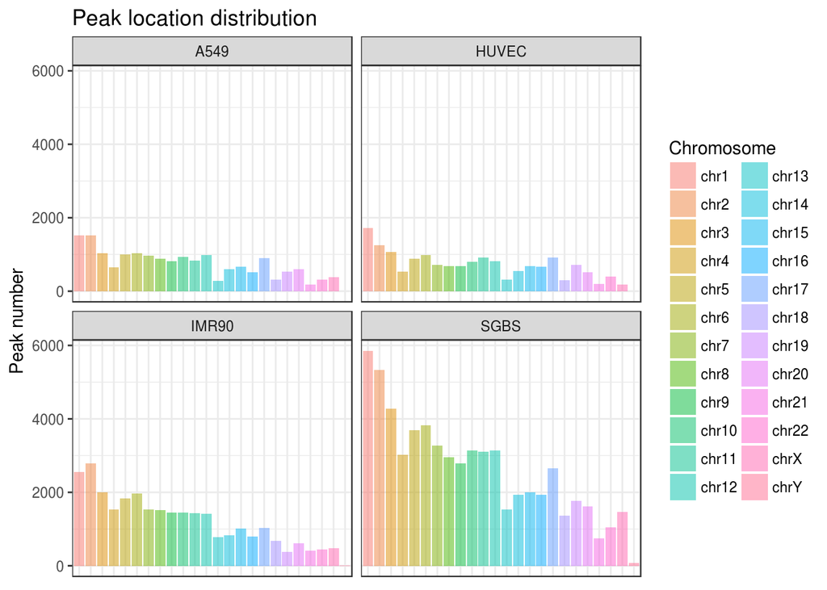

Ну что, выглядит вполне красиво и логично - у нас есть пики, которые во всех линиях распределены примерно одинаково, значит, с данными все относительно хорошо.

Чтобы избавиться от шума,бинаризуем пики окошком в 50 п.о., напишем для этого небольшую функцию.

```r
bin.peaks <- function(dataframe, window_size = 50, append = TRUE)
{
  #Эта функция выдает номера бинов в диапазоне [START, STOP]
  fun <- function(Start, Stop)
  {
    bin_start <- floor(Start/window_size)*window_size
    bin_stop <- ceiling(Stop/window_size)*window_size - window_size
    positions <- seq(bin_start, bin_stop, by = window_size)
  return(positions)
  }

  if (append == TRUE){
    dataframe$Peak_Bins <- mapply(fun, dataframe$Start, dataframe$Stop)
    return(dataframe)
  }else{
    bin_vector <- unlist(mapply(fun, dataframe$Start, dataframe$Stop))
    bin_vector <- sort(bin_vector)
    return(bin_vector)
  }
}
```

Теперь бинаризуем, и добавим для этого столбец Peak_Bins

```r
all_peaks <- bin.peaks(all_peaks, window_size = 50)

#Выделим для каждого бина отдельную строку, чтобы было удобнее. Для этого возьмем функцию unnest из пакетика tidyr
all_bins <- unnest(all_peaks, Peak_Bins)
all_bins <- as.data.table(all_bins)
```

Наступает время корреляций! Для начала посмотрим на корреляции всех пиков между различными клеточными линиями, убрав, разумеется, Y-хромосому, иначе сравнивать некорректно, так как у нас есть женские линии. При недостатке пиков будем добавлять нули, чтобы не обрезать информативные пики в более длинных датасетах

```r
A549 <- subset(all_bins$Peak_Bins, all_bins$Cell_line =="A549" & all_bins$Chromosome !="chrY")

HUVEC <- subset(all_bins$Peak_Bins, all_bins$Cell_line =="HUVEC" & all_bins$Chromosome !="chrY")

IMR90 <- subset(all_bins$Peak_Bins, all_bins$Cell_line =="IMR90" & all_bins$Chromosome !="chrY")

SGBS <- subset(all_bins$Peak_Bins, all_bins$Cell_line =="SGBS" & all_bins$Chromosome !="chrY")

cor_table <- cbind("A549" = A549,
                   "HUVEC" = HUVEC,
                   "IMR90" = IMR90,
                   "SGBS" = SGBS)
```

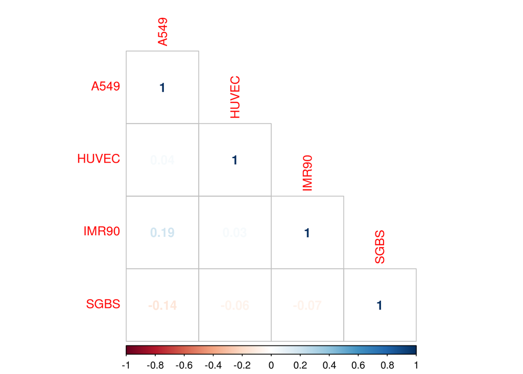

```r
M <- cor(cor_table, method = "pearson")
#cor.test (HUVEC, sample(A549, length(HUVEC)))
corrplot(M, method = "number", type = "lower")
```

```r
remove(M)
```

Теперь построим корреляционную матрицу между не самыми мощными пиками fold_change =< 15. Что я думаю, что они должны лучше коррелировать

```r
A549 <- subset(all_bins$Peak_Bins, all_bins$Cell_line =="A549" & all_bins$Chromosome !="chrY" & all_bins$fold_change <= 15)

HUVEC <- subset(all_bins$Peak_Bins, all_bins$Cell_line =="HUVEC" & all_bins$Chromosome !="chrY" & all_bins$fold_change <= 15)

IMR90 <- subset(all_bins$Peak_Bins, all_bins$Cell_line =="IMR90" & all_bins$Chromosome !="chrY" & all_bins$fold_change <= 15)

SGBS <- subset(all_bins$Peak_Bins, all_bins$Cell_line =="SGBS" & all_bins$Chromosome !="chrY" & all_bins$fold_change <= 15)


cor_table <- cbind("A549" = A549,
                   "HUVEC" = HUVEC,
                   "IMR90" = IMR90,
                   "SGBS" = SGBS)
```

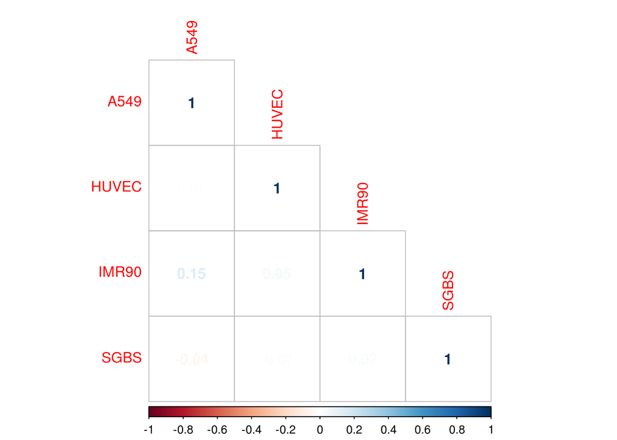

```r
M <- cor(cor_table, method = "pearson")
corrplot(M, method = "number", type = "lower")
```

```r
remove(M)
```

И что, видим то же самое, никаких принципиальных изменений

Теперь попробуем с самыми мощными

```r
A549 <- subset(all_bins$Peak_Bins, all_bins$Cell_line =="A549" & all_bins$Chromosome !="chrY" & all_bins$fold_change > 15)

HUVEC <- subset(all_bins$Peak_Bins, all_bins$Cell_line =="HUVEC" & all_bins$Chromosome !="chrY" & all_bins$fold_change > 15)

IMR90 <- subset(all_bins$Peak_Bins, all_bins$Cell_line =="IMR90" & all_bins$Chromosome !="chrY" & all_bins$fold_change > 15)

SGBS <- subset(all_bins$Peak_Bins, all_bins$Cell_line =="SGBS" & all_bins$Chromosome !="chrY" & all_bins$fold_change > 15)

cor_table <- cbind("A549" = A549,
                   "HUVEC" = HUVEC,
                   "IMR90" = IMR90,
                   "SGBS" = SGBS)
```

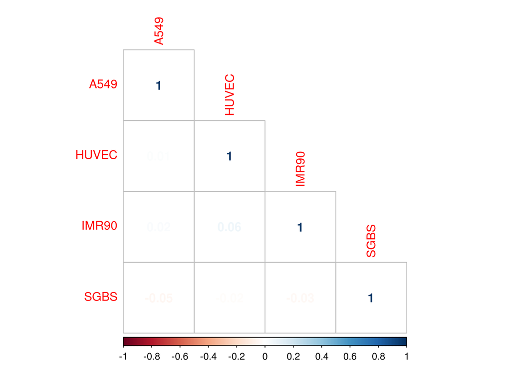

```r
M <- cor(cor_table, method = "pearson")
corrplot(M, method = "number", type = "lower")
```

```r
remove(M)
```

Ну вообще совсем ничего, то есть корреляцию делают только маленькие пики. А теперь построим картинку с диаграммой Венна, чтобы посмотреть, какие пики у нас везде есть.

[figure not shown]

```r
#Сделаем список, VennDiagram принимает только списки

bins_plot <- list(A549 = subset(all_bins$Peak_Bins, all_bins$Cell_line == "A549"),
                  HUVEC = subset(all_bins$Peak_Bins, all_bins$Cell_line == "HUVEC"),
                  IMR90 = subset(all_bins$Peak_Bins, all_bins$Cell_line == "IMR90"),
                  SGBS = subset(all_bins$Peak_Bins, all_bins$Cell_line == "SGBS"))

bin_plot1 <- venn.diagram(bins_plot, NULL,
  col = "transparent",
    fill = c("cornflowerblue", "green", "yellow", "darkorchid1"),
    alpha = 0.50,
    #label.col = c("orange", "white", "darkorchid4", "white",
    #"white", "white", "white", "white", "darkblue", "white",
    #"white", "white", "white", "darkgreen", "white"),
    cex = 1.5,
  print.mode = "percent",
  cat.col = c("darkblue", "darkgreen", "orange", "darkorchid4"),
    category.names=c("A549", "HUVEC", "IMR90", "SGBS"),
                          main="Пересечение пиков")

bin_plot2 <- venn.diagram(bins_plot, NULL,
  col = "transparent",
    fill = c("cornflowerblue", "green", "yellow", "darkorchid1"),
    alpha = 0.50,
    #label.col = c("orange", "white", "darkorchid4", "white",
    #"white", "white", "white", "white", "darkblue", "white",
    #"white", "white", "white", "darkgreen", "white"),
    cex = 1.5,
  print.mode = "raw",
  cat.col = c("darkblue", "darkgreen", "orange", "darkorchid4"),
    category.names=c("A549", "HUVEC", "IMR90", "SGBS"),
                          main="Пересечение пиков")

grid.draw(bin_plot1)

grid.draw(bin_plot2)
```

```r
common_bins_1 <- fintersect(all_bins[all_bins$Cell_line =="A549", "Peak_Bins"],
                  all_bins[all_bins$Cell_line =="HUVEC", "Peak_Bins"])

common_bins_2 <-  fintersect(all_bins[all_bins$Cell_line =="IMR90", "Peak_Bins"],
                  all_bins[all_bins$Cell_line =="SGBS", "Peak_Bins"])

common_bins <- fintersect(common_bins_1, common_bins_2)
common_bins <- common_bins$Peak_Bins

remove(common_bins_1,common_bins_2)
```

Уху! Что же мы видим, у нас есть 12873 общих бинов, которые есть везде, во всех клеточных линиях. Отберем их для начала.

Теперь наконец-то притянем аннотацию

Или наоборот, притянем аннотацию ручками из GFF-файла и сохраним ее в отдельном файле Для этих операций используем library(data.table)

```r
#Uncomment if you want to make new annotaton from the GFF3
#raw_gff <- fread( "sed '/#/d' /home/nickolay/Human_genome/Genprime_v24/gencode.v24.annotation.gff3")
#raw_gff[,c(2,6,8)] <- NULL

#raw_gff$V9 <- strsplit(raw_gff$V9, ";")
#raw_gff$ID <- sapply(raw_gff$V9,function(x) x[1])
#raw_gff$ID <- gsub("ID=\\w*:?E", "E", raw_gff$ID)

#annotation_v24 <- raw_gff[,c(1:5, 7)]
#rownames(annotation_v24) <- NULL
#annotation_v24$V1 <- NULL
#names(annotation_v24) <- c("Chromosome", "Type", "Start", "Stop", "Strand", "Ensemble_ID")

#fwrite(annotation_v24, file = "Annotation/Gencode_v24.bed", sep = "\t")

annotation_v24 <- fread("Annotation/Gencode_v24.bed")
```

```
##
Read 49.8% of 2570242 rows
Read 88.3% of 2570242 rows
Read 2570242 rows and 6 (of 6) columns from 0.123 GB file in 00:00:04
```

```r
#Теперь вытащим только транскрипты
transcripts <- subset(annotation_v24, annotation_v24$Type == "transcript")
transcripts$Type <- NULL
fwrite(transcripts, "Annotation/transcripts.bed", sep = "\t", col.names = FALSE)
```

Не будем изобретать велосипед, а сделаем скрипт, который с помощью bedtools найдет нам ближайшие гены.

```bash
cd ~/R_stuff/NF-kB_sites/Annotation
#Отсортируем файл с транскриптами и с пиками
sortBed -i transcripts.bed > sorted_transcripts.bed
sortBed -i peaks.bed > sorted_peaks.bed

#А теперь пошли фичи искать
closestBed -D b -k 2 -a sorted_peaks.bed -b sorted_transcripts.bed > closest_transcripts.bed
```

Окей, нашли ближайшие транскрипты, отфильруем их

```r
features <- fread("Annotation/closest_transcripts.bed")
names(features) <- c("Chromosome", "peak_Start", "peak_Stop", "Peak_name",
                             "Fold_change", "p-value", "q-value", "Cell_line",
                     "Chr", "transcript_Start", "transcript_Stop", "Strand",
                     "Ensemble_ID", "distance")
features$Chr <- NULL
# Убрали пики, которые лежат очень далеко в пустоте, т.е. от них до гена более 3000 нуклеотидов

features <- subset(features, features$distance<3000 & features$distance > - 3000)

#Удалим хвостики у названий транскриптов
features$Ensemble_ID <- gsub("\\.\\d+", "", features$Ensemble_ID)
```

Теперь попробуем проаннотировать гены по GO

```r
library(biomaRt)

# define biomart object
mart <- useMart(biomart = "ensembl", dataset = "hsapiens_gene_ensembl")

# query biomart
BM_out <- getBM(attributes = c("chromosome_name","ensembl_transcript_id",
                               "uniprotswissprot", "hgnc_symbol",
                               "transcript_biotype", "name_1006",
                                "namespace_1003"),
                 filters = "ensembl_transcript_id",
                values = features$Ensemble_ID,
                mart = mart,
                uniqueRows = TRUE)
```

Теперь, когда у нас есть огромная аннотация, надо ее расчистить

```r
#Удалим неинформативные GO
BM_out <- BM_out[BM_out$name_1006 != "molecular_function" &
                  BM_out$name_1006 != "cellular_component" &
                   BM_out$name_1006 != "biological_process" ,]

GO_data <-BM_out %>% group_by(namespace_1003, ensembl_transcript_id)
names(GO_data) <- c("Chromosome", "Ensemble_ID", "Uniprot_ID", "Gene_symbol", "Biotype",  "GO_name", "Namespace")
```

Славно, теперь давай прихуярим высоту пиков

```r
#Сделаем маленький датасет со всем необходимым
features <- features[ , c("Ensemble_ID", "distance", "peak_Start", "peak_Stop","Cell_line", "Fold_change", "p-value", "q-value")]

final_peaks <- merge(GO_data, features)
fwrite(final_peaks, "final_peaks.txt")
```

Вот и славно,все вроде заджойнилось Теперь давай-ка глянем на функции, которые у нас вылезли по GO:

```r
mf_table <- table(subset(final_peaks$GO_name, final_peaks$Namespace == "molecular_function"))

cc_table <- table(subset(final_peaks$GO_name, final_peaks$Namespace == "cellular_component"))

bp_table <- table(subset(final_peaks$GO_name, final_peaks$Namespace == "biological_process"))

head(sort(mf_table, decreasing = T))
```

```
##
##      protein binding    metal ion binding          DNA binding
##                 9319                 3672                 2603
##   nucleotide binding          ATP binding transferase activity
##                 2541                 2036                 1827
```

```r
head(sort(bp_table, decreasing = T))
```

```
##
##                           regulation of transcription, DNA-templated
##                                                                 3052
##                                         transcription, DNA-templated
##                                                                 2506
##                                                  signal transduction
##                                                                 1938
##                                                            transport
##                                                                 1547
## positive regulation of transcription from RNA polymerase II promoter
##                                                                 1353
##                               positive regulation of GTPase activity
##                                                                 1054
```

```r
head(sort(cc_table, decreasing = T))
```

```
##
##                       membrane                      cytoplasm
##                           7387                           7023
##                        nucleus                        cytosol
##                           6381                           6116
##                plasma membrane integral component of membrane
##                           4953                           4641
```

Что теперь надо построить:

1. Какие функции обогащены в самых высоких пиках (Хи-квадрат)
2. Какие пики самые достоверные по q-value во всех линиях
3. Насколько похожи функции в топовых пиках в разных клеточных линиях(ранжированный список)
4. Взять 10 NF-kB зависимых генов и посмотреть, где они лежат в рейтинге
5. Средние высоты пиков для каждой из top 10 функций

Посмотрим, на то, как распределены гены относительно TSS

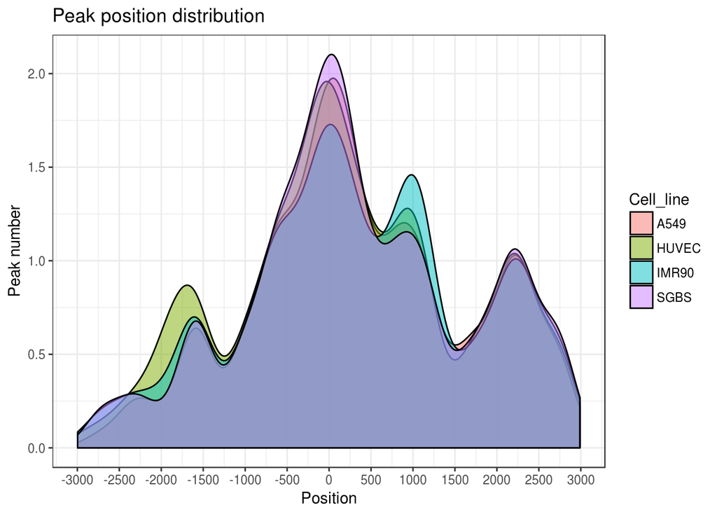

```r
ggplot(final_peaks[final_peaks$distance!=0,], aes(distance, ..count..))+
  geom_density(aes(fill=Cell_line), alpha = 0.5) +
  labs(title = "Peak position distribution",
       x = "Position",
       y = "Peak number")+
    scale_x_continuous(breaks = seq(-3000, 3000, 500))+
  theme_bw()
```

Прикольно, что одинаково распределены!

Какие гены активируются во всех пиках (biotype-boxplot)(Доделать подписи)

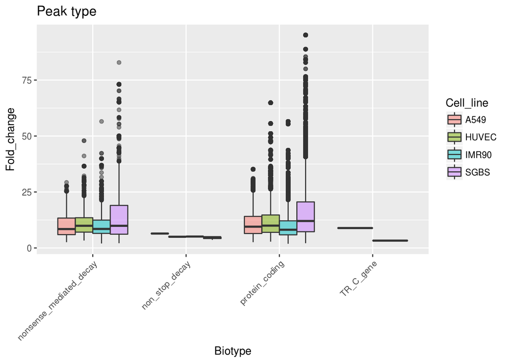

```r
ggplot(final_peaks, aes(Biotype, Fold_change))+
  geom_boxplot(aes(fill=Cell_line), alpha = 0.5) +
  labs(title = "Peak type",
       x = "Biotype",
       y = "Fold_change")+
  scale_colour_manual(breaks = c("Nonsense-mediated decay", "non-stop decay", "Protein coding", "TCR's")) +
  theme(axis.text.x = element_text(angle = 45, vjust = 1, hjust=1))
```

Теперь можно и взглянуть на обогащение терминов в разных клеточных линиях Для этого возьмем топ 10% пиков

```r
top_mf_table_A549 <- table(subset(final_peaks$GO_name,
                         final_peaks$`q-value` > quantile
                         (final_peaks$`q-value`, probs=0.90),
                         final_peaks$Cell_line == "A549",
                         final_peaks$Namespace == "molecular_function"))

top_mf_table_HUVEC <- table(subset(final_peaks$GO_name,
                         final_peaks$Fold_change > quantile
                         (final_peaks$Fold_change, probs=0.90),
                         final_peaks$Cell_line == "HUVEC",
                         final_peaks$Namespace == "molecular_function"))


head(sort(top_mf_table_HUVEC, decreasing = T))
```

[output not shown]

```r
head(sort(cc_table, decreasing = T))
```

```
##
##                       membrane                      cytoplasm
##                           7387                           7023
##                        nucleus                        cytosol
##                           6381                           6116
##                plasma membrane integral component of membrane
##                           4953                           4641
```

```r
cc_table <- table(subset(final_peaks$GO_name, final_peaks$Namespace == "cellular_component"))

bp_table <- table(subset(final_peaks$GO_name, final_peaks$Namespace == "biological_process"))

head(sort(mf_table, decreasing = T))
```

```
##
##      protein binding    metal ion binding          DNA binding
##                 9319                 3672                 2603
##   nucleotide binding          ATP binding transferase activity
##                 2541                 2036                 1827
```

```r
head(sort(bp_table, decreasing = T))
```

```
##
##                           regulation of transcription, DNA-templated
##                                                                 3052
##                                         transcription, DNA-templated
##                                                                 2506
##                                                  signal transduction
##                                                                 1938
##                                                            transport
##                                                                 1547
## positive regulation of transcription from RNA polymerase II promoter
##                                                                 1353
##                               positive regulation of GTPase activity
##                                                                 1054
```

```r
head(sort(cc_table, decreasing = T))
```

```
##
##                       membrane                      cytoplasm
##                           7387                           7023
##                        nucleus                        cytosol
##                           6381                           6116
##                plasma membrane integral component of membrane
##                           4953                           4641
```